# Module 1: Professional Communication & Corporate Presence (7.5 Hours)

NOT English Language Learning - This is Business Communication

Author

Global Scholastics

Abstract

Session 1: Mastering the art of Email writing

# Module 1: Session 1 - The High-Stakes Email (1.5 Hours)

## Complete Facilitator Materials & Student Resources

## **PRE-SESSION SETUP**

### Materials Needed:

- Projector/screen for email examples
- Printed handouts (3 pages per student)
- Timer (visible to class)
- Whiteboard/flipchart

### Room Setup:

- Tables arranged for pair work
- Each student needs writing space

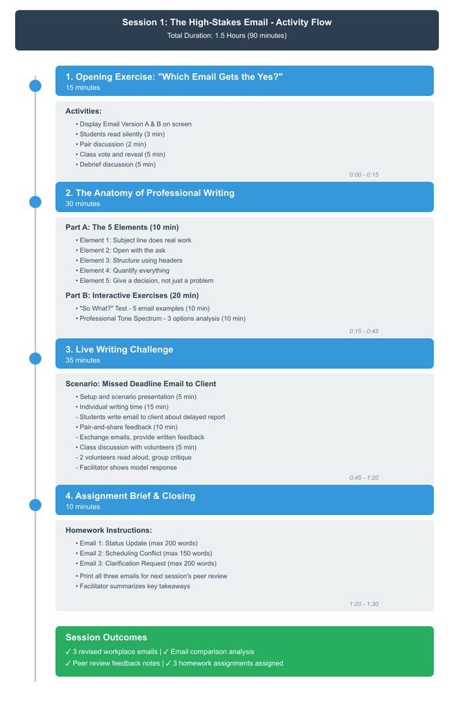

## **OPENING EXERCISE: “Which Email Gets the Yes?” (15 minutes)**

### Facilitator Script:

“Good morning. We’re going to start with a real situation that happened at an Indian IT services company last month. A project manager needed additional budget approval. She sent an email to her director. I’m going to show you two versions—only one is real. Your job: figure out which one got approved in 2 hours, and which one got ignored for a week.”

### Display on Screen - EMAIL VERSION A:

```
Subject: Budget Request

Hi Rajesh Sir,

I hope this email finds you well and you are doing great. I am writing to you today because I wanted to discuss something important related to our project.

As you know, we have been working on the Customer Portal Migration project for the past few months and the team has been putting in a lot of effort. However, we are facing some challenges that I thought I should bring to your attention.

The thing is, we initially estimated the cloud infrastructure costs based on the vendor's standard pricing, but now they have informed us that due to the data residency requirements for BFSI clients, we need to opt for their premium tier. This was not something we had anticipated earlier.

Because of this unexpected development, we are looking at additional costs. The current budget allocated was ₹12 lakhs for infrastructure, but now we are looking at around ₹15-16 lakhs approximately. I wanted to check with you if we can get additional budget approval for this.

Please let me know your thoughts on this matter at your earliest convenience. I am happy to discuss this further if you need any clarification.

Looking forward to your response.

Regards,
Priya
```

### Display on Screen - EMAIL VERSION B:

```
Subject: Customer Portal Migration - Budget Approval Required (₹3.8L)

Hi Rajesh,

I need budget approval for additional infrastructure costs on the Customer Portal Migration project.

**Situation:**
Our vendor (AWS) requires premium tier for BFSI data residency compliance—not included in original scope.

**Financial Impact:**
- Original budget: ₹12L
- Additional required: ₹3.8L
- New total: ₹15.8L

**Why this matters:**
Without premium tier, we cannot meet RBI data localization requirements. Project would fail compliance audit.

**Timeline:**
Vendor needs commitment by March 15 to maintain our go-live date (March 30).

**My recommendation:**
Approve ₹3.8L increase. Alternative is 6-week delay while we re-architect for different vendor (estimated cost: ₹8L+ in developer time).

Can we discuss this today? I'm available 2-4 PM or tomorrow morning.

Priya Sharma
Project Manager, Digital Transformation
Ext: 4521
```

### Activity Instructions:

**Step 1 (3 minutes):** “Read both emails silently. Think: Which one would you approve if you were the director?”

**Step 2 (2 minutes):** “Turn to your neighbor. Share your vote and why.”

**Step 3 (5 minutes):** “Show of hands—who thinks Email A got approved?” (count) “Who thinks Email B?” (count)

**Step 4 - The Reveal (5 minutes):**

“Email B got approved in 2 hours with a one-line response: ‘Approved. Send PO to finance.’ Email A was ignored for a week, then sent back with ‘Please provide detailed breakdown and alternatives.’”

**Debrief Questions (facilitate discussion):**

1. “What did Email B do that Email A didn’t?”
   - *(Expected answers: specific numbers, clear deadline, recommendation, alternative considered)*
2. “Email A is longer and more polite. Why didn’t that help?”
   - *(Expected answers: buried the main point, no urgency, forced manager to ask follow-up questions)*
3. “What does ‘at your earliest convenience’ actually mean to a busy director?”
   - *(Expected answer: nothing urgent = I’ll get to it when I have time = never)*

### Key Teaching Moment:

“In professional communication, **politeness is expected, but clarity is required.** Email A was polite but made the manager do extra work. Email B made it easy to say yes. That’s the difference between academic writing and business writing.”

## **THE ANATOMY OF PROFESSIONAL WRITING (30 minutes)**

### Facilitator Presents: The 5 Elements of Email B

Project Email B back on screen. Walk through each element:

### Element 1: The Subject Line Does Real Work

**Bad:** “Budget Request” *(What budget? How much? When?)* **Good:** “Customer Portal Migration - Budget Approval Required (₹3.8L)” *(I know what this is before opening)*

**Principle:** Your subject line should answer: What is this about + What do you need from me?

### Element 2: Open With The Ask

“Compare the opening lines: - Email A: ‘I hope this email finds you well…’ - Email B: ‘I need budget approval…’

Which one respects the reader’s time?”

**Principle:** State your purpose in the first sentence. Warm-up pleasantries waste time in written communication.

### Element 3: Structure Using Headers

“Notice Email B uses bold headers: Situation, Financial Impact, Why This Matters, Timeline, My Recommendation.

Why? Because busy managers **scan, they don’t read.** Headers let them jump to what they care about.”

**Principle:** Make your email scannable. Use bullets, numbers, bold text strategically.

### Element 4: Quantify Everything

“Email A says ‘additional costs’ and ‘around ₹15-16 lakhs approximately.’ Email B says ‘Additional required: ₹3.8L’

Which one sounds more professional?”

**Principle:** Vague = unprepared. Specific = credible.

### Element 5: Give Them A Decision, Not Just A Problem

“Email A asks: ‘Please let me know your thoughts’ Email B says: ‘My recommendation: Approve ₹3.8L increase. Alternative is…’

What’s the difference?”

**Principle:** Your manager’s job is to choose between options, not to create options. Do that work for them.

### Interactive Exercise: The “So What?” Test (10 minutes)

**Instructions:**

“I’m going to show you 5 sentences from real business emails. For each one, ask yourself: Would my manager read this and think ‘So what? Why does this matter?’”

**Project on screen:**

1. “The meeting has been rescheduled.”
   - **So What?** *(To when? Do I need to do anything?)*
   - **Better:** “The client meeting moved from March 15 to March 18, 2 PM. Same Zoom link.”
2. “There are some issues with the vendor deliverable.”
   - **So What?** *(What issues? How bad? What’s the impact?)*
   - **Better:** “The vendor’s API documentation is missing 3 critical endpoints. Our developers cannot integrate without this. I’ve requested it by COB today.”
3. “Please find the attached report.”
   - **So What?** *(What report? What should I do with it?)*
   - **Better:** “Attached is Q3 sales analysis. Key finding: North region down 18%. Recommend we discuss recovery plan in Friday’s meeting.”
4. “I wanted to follow up on my previous email.”
   - **So What?** *(Which email? What did you need?)*
   - **Better:** “Following up on budget approval request (sent March 10). Need your decision by March 15 to meet vendor deadline.”
5. “Thanks for your time and consideration.”
   - **So What?** *(Generic closing = filler)*
   - **Better:** “Let me know if you need the vendor contract for review.”

**Teaching Point:**

“Every sentence must answer: Why does the reader need to know this? If you can’t answer that, delete the sentence.”

### The Professional Tone Spectrum (10 minutes)

**Facilitator presents scenario:**

“You discover an error in a colleague’s report that was sent to the client. It’s factually wrong and could damage credibility. How do you handle this?”

**Show 3 options on screen:**

**Option 1 - Too Blunt:**

```
Hi Amit,

The revenue figure in slide 7 is wrong. It's ₹45L, not ₹54L. This needs to be corrected immediately.
```

**Option 2 - Too Soft:**

```
Hi Amit,

I hope you're doing well! I was just glancing through the presentation and I think maybe there might possibly be a small typo in one of the slides? The revenue number seems a bit different from what I remember. Not sure if it matters, but just wanted to mention it! No pressure at all.
```

**Option 3 - Professional:**

```
Hi Amit,

I noticed the revenue figure on slide 7 shows ₹54L. Our finance dashboard shows ₹45L for the same period. Could you double-check which number is correct? If it's ₹45L, we should send a corrected version to the client today.

Happy to help verify if needed.
```

**Discussion (5 minutes):**

“What makes Option 3 work? - It states the problem clearly (factual, not accusatory) - It acknowledges both of you might have different data (not assuming error) - It suggests action with urgency (but not panic) - It offers help (collaborative, not critical)

This is **diplomatic directness**—the tone Indian corporate culture values most.”

## **LIVE WRITING CHALLENGE (35 minutes)**

### Setup (5 minutes)

**Facilitator announces:**

“Now you’re going to write under real conditions. Here’s your scenario—and yes, this is based on a real incident.”

### SCENARIO (display on screen):

```
You are Neha Kapoor, a Business Analyst at TechConsult India.

SITUATION:
Your team was supposed to deliver a market analysis report to your client (Apex Retail Ltd.) by yesterday, 5 PM. You missed the deadline because:
- Your team lead (Rahul) was sick for 3 days
- Two data sources were delayed by vendors
- You personally underestimated the time needed for analysis

THE CLIENT:
Sanjay Mehta, VP of Strategy at Apex Retail. He's professional but demanding. This is his second project with your firm. The report informs a board meeting scheduled for tomorrow afternoon.

YOUR TASK:
Write the email to Sanjay Mehta. You need to:
1. Acknowledge the missed deadline
2. Explain what happened (without making excuses)
3. Tell him when he'll receive it
4. Maintain his confidence in your team

You have 15 minutes. Begin.
```

### Individual Writing (15 minutes)

- Students write silently
- Instructor walks around, observes (but doesn’t comment yet)
- Set visible timer

### Pair-and-Share Feedback (10 minutes)

**Instructions:**

“Exchange your email with the person next to you. Read theirs carefully. Then answer these questions:

1. Did they acknowledge the problem clearly in the first sentence?
2. Did they give a specific new deadline?
3. Did they take responsibility without over-apologizing?
4. Would you trust this team if you were the client?

Write your feedback at the bottom of their page. Be specific: what worked, what didn’t.”

**Facilitator asks for 2 volunteers to read their emails aloud.**

After each reading, facilitate discussion:

- “What did this email do well?”
- “If you were the client, what questions would you still have?”
- “How could this be improved?”

**Facilitator then shows a model response:**

```
Subject: Market Analysis Report - Revised Delivery: Tomorrow 11 AM

Hi Sanjay,

We missed yesterday's 5 PM deadline for the Apex Retail market analysis. I apologize for this delay.

**What happened:**
Our team lead was unexpectedly unavailable, and two vendor data sources arrived 48 hours late. I also underestimated the analysis time required.

**Current status:**
The report is 85% complete. All data is now in hand, and I'm personally finalizing the analysis and recommendations sections.

**New commitment:**
You'll have the complete report by tomorrow (March 16) at 11 AM—well before your 3 PM board meeting.

**Quality assurance:**
Despite the delay, we're maintaining full analytical rigor. Our Senior Partner, Ms. Kavita Shah, is reviewing the final draft tonight.

I understand this impacts your preparation time. If you'd like a 30-minute briefing call before the board meeting, I'm available tomorrow between 12-2 PM.

Neha Kapoor
Business Analyst, TechConsult India
+91 98765 43210
```

**Debrief:**

“Notice what this email does: - Opens with the bad news directly (no hiding) - Takes responsibility (doesn’t blame teammates publicly) - Gives a specific, achievable deadline (with buffer before client’s board meeting) - Reassures about quality (senior partner reviewing) - Offers additional support (briefing call)

This is crisis communication done right.”

## **ASSIGNMENT BRIEF (10 minutes)**

### Homework Instructions (Project on Screen + Handout)

“For next session, you’ll write THREE emails. Print them out and bring physical copies—we’ll do peer review workshops.”

### Assignment Sheet:

**EMAIL 1: The Status Update**

**Scenario:** You’re a Junior Marketing Executive. Your manager asked you to “send a quick update on the social media campaign.” The campaign launched 2 weeks ago.

**What to include:** - Key metrics (reach, engagement, conversions) - What’s working, what’s not - Any issues or changes needed - Max 200 words

**EMAIL 2: The Scheduling Conflict**

**Scenario:** Your colleague Priya scheduled a team meeting for Thursday 3 PM. You have a client call at that exact time that cannot be moved. You need to either attend a different time slot or get meeting notes.

**Write the email to Priya.**

Requirements: - Polite but clear about your conflict - Offer solutions (not just problems) - Don’t over-apologize - Max 150 words

**EMAIL 3: The Clarification Request**

**Scenario:** Your manager sent you a vague instruction: “Can you look into the vendor payment delays and fix whatever’s causing issues?”

You don’t know: - Which vendors? - What kind of delays? - What authority you have to “fix” anything - What deadline she expects

**Write the email asking for clarification without sounding clueless.**

Requirements: - Show you’ve thought about the problem - Ask specific questions - Suggest a plan of action pending her input - Max 200 words

### Facilitator Closing (2 minutes)

“What you learned today: 1. Clarity beats politeness when they conflict 2. Structure your writing for scanning, not reading 3. Every sentence must pass the ‘So What?’ test 4. Give decisions, not just information

Next session: We’ll practice writing under pressure with tight deadlines. Bring your homework printed out. See you then.”

## **FACILITATOR NOTES & TEACHING TIPS**

### Common Student Mistakes to Watch For:

1. **Over-apologizing:** Students from academic backgrounds often write “I’m extremely sorry” three times. Coach them: apologize once, then focus on the solution.
2. **Burying the lead:** They write 3 paragraphs of context before stating what they need. Redirect: “Start with the ask.”
3. **Vague language:** “Soon,” “ASAP,” “some issues.” Push for specifics: “By when exactly?” “What issues specifically?”
4. **Fear of being direct:** Cultural tendency to soften everything. Teach: “Direct ≠ rude. Direct = respectful of time.”

### Time Management:

- If opening exercise runs long (students enjoying debate), cut Element 5 discussion short
- If students struggle with writing challenge, extend to 20 minutes and reduce pair feedback to 5 minutes
- Always protect the final 10 minutes for homework assignment

### Differentiation:

- **Advanced students:** Challenge them to write the client email in under 100 words without losing key information
- **Struggling students:** Give them a template structure: “Opening (problem) → Explanation (brief) → Solution (specific) → Next steps (clear)”

### Assessment Signals:

Watch for students who: - ✅ Use specific numbers and dates - ✅ Front-load their main point - ✅ Structure with headers/bullets - ❌ Write long paragraphs with no breaks - ❌ Use passive voice (“It was decided that…”) - ❌ End with vague “Let me know” instead of specific call to action

## **HANDOUTS TO PRINT (3 pages per student)**

### Page 1: The Email Comparison (both versions A & B)

### Page 2: The “So What?” Test examples + Professional Tone Spectrum

### Page 3: Homework Assignment Sheet with all three email scenarios

**END OF SESSION 1 MATERIALS**